# Benchmark

# Problema da Contagem de Intersecções

Dada uma tabela com duas colunas **letra** e **número** aonde **letra** é uma letra do alfabeto [A..Z] randomincamente selecionada e **número** é um número entre [0,10] também randomicamente selecionado. O objetivo desde problema é produzir uma nova tabela contendo três colunas: letra inicial (letra_i), letra final (letra_f) e peso, de modo que o peso corresponda a quantidade de vezes que o mesmo número ocorre simultaneamente entre *letra_i* e *letra_f*.

**Exemplo 1:**

*input*:

| letra | numero |
| --- | --- |
| A | 5 |
| B | 3 |
| C | 5 |
| D | 3 |
| E | 3 |
| G | 1 |

*output*:

[output not shown]

**Exemplo 2**

*input*:

| letra | valor |
| --- | --- |
| A | 5 |
| B | 3 |
| C | 5 |
| A | 3 |
| B | 1 |
| C | 1 |

*output*:

| letra_i | letra_f | peso |
| --- | --- | --- |
| A | B | 1 |
| A | C | 1 |
| B | C | 1 |

**Contruindo as bases de dados:**

```r
library(dplyr)

dataset_builder <- function(qt_dataset){
  set.seed(123)
  dados <- tibble(LETRAS = sample(LETTERS, qt_dataset, replace = TRUE),
                  NUMEROS = sample(1:qt_dataset, qt_dataset, replace = TRUE)
                  )

  tabela <- tapply(X = dados$NUMEROS, INDEX = dados$LETRAS, unique)
  return(tabela)
}
```

**Versão original:**

```r
fernando <- function(tabela){

  data_F <- data.frame(letra_i = NA, letra_j = NA, peso = NA)
  total <- length(tabela)

  for(i in c(1:total)){
    for(j in c(1:total)) {
      peso <- sum(tabela[[i]] %in% tabela[[j]])
      letra_i <- names(tabela[i])
      letra_j <- names(tabela[j])
      data_F[paste0(i,"-",j),] <- c(letra_i, letra_j, peso)
    }
  }

  data_F <- data_F[-1, ] #remove primeira linha de NAs
  data_F <- transform(data_F, peso = as.integer(peso))
  row.names(data_F) <- NULL

  return(data_F)
}
```

**Versão de João Isídio:**

```r
library(tidyr)

joao <- function(tabela){

  # Cria uma matriz triangular de postos
  # somando as ocorrências similares nas celulas
  data_J <- sapply(X = tabela,
                   FUN = function(y){
                             lapply(X = tabela,
                                    FUN = function(x){
                                             sum(x %in% y)
                                          }
                                    )
                         }
                  )

  data_J <- data_J %>% as.data.frame()
  data_J$letra_i <- rownames(data_J)
  data_J <- gather(data = data_J, key = "letra_j", value = "peso", -letra_i)
  data_J$peso <- unlist(data_J$peso)
  data_J <- data_J %>% arrange(letra_i, letra_j)
  return(data_J)
}
```

**Versão Tomás:**

```r
library(tidyverse)

tomas <- function(tabela){

  qtd_in <- function(a, b) {
    sum(a %in% b)
  }

  data_T <- map_df(tabela, ~map_int(tabela, qtd_in, b = .x)) %>%
            mutate(linha = names(tabela)) %>%
            pivot_longer(-linha)

  colnames(data_T) <- c('letra_i', 'letra_j', 'peso')
  data_T <- transform(data_T, peso = as.integer(peso))

  return(data_T)

}
```

**Comparador de eficiências:**

```r
library(microbenchmark)

bech_mark <- function(size){
  tabela <- dataset_builder(size)
  comp <- microbenchmark("fernando" = {df_original <- fernando(tabela)},
                       "tomas" = {df_tomas <- tomas(tabela)},
                       "joao" = {df_joao <- joao(tabela)},
                       check = 'identical')
  df <- print(comp)
  df$ds_size <- size
  return(df)
}
```

Resultados:

```r
p1 <- bech_mark(100)
```

```
## Unit: milliseconds
##      expr       min        lq      mean    median        uq      max neval
##  fernando 41.212100 43.237701 44.850192 44.476301 46.351651  53.0535   100
##     tomas 90.968301 92.394400 93.724955 93.445951 94.350801 108.4297   100
##      joao  5.506301  5.888801  6.955028  6.107901  6.594551  68.8010   100
```

```r
p2 <- bech_mark(1000)
```

```
## Unit: milliseconds
##      expr       min         lq       mean     median         uq      max neval
##  fernando 46.864701  48.519751  52.165456  51.510551  53.468902 115.1322   100
##     tomas 96.795001 100.192951 104.287157 102.445001 106.136151 142.0691   100
##      joao  6.433601   6.894701   7.447867   7.248151   7.680851  11.3547   100
```

```r
p3 <- bech_mark(10000)
```

```
## Unit: milliseconds
##      expr      min       lq      mean   median        uq      max neval
##  fernando  54.4399  56.0968  58.92211  58.5764  60.18445 119.4822   100
##     tomas 103.3545 105.1273 107.07279 106.1444 107.13255 174.4157   100
##      joao  12.2644  12.7663  13.60111  12.9908  13.77935  19.5193   100
```

```r
p4 <- bech_mark(100000)
```

```
## Unit: milliseconds
##      expr      min       lq     mean   median       uq      max neval
##  fernando 183.0422 184.8560 188.0514 185.9076 188.0159 247.5125   100
##     tomas 220.0791 224.7666 227.6387 225.6762 227.5061 285.7209   100
##      joao 131.8992 133.2152 134.1970 133.8553 134.7100 140.5449   100
```

```r
p5 <- bech_mark(1000000)
```

```
## Unit: milliseconds
##      expr      min       lq     mean   median       uq      max neval
##  fernando 802.9163 810.7722 833.2047 815.3458 840.1492 982.7220   100
##     tomas 832.9215 841.9687 860.0039 845.7246 863.3824 986.5704   100
##      joao 741.3807 748.5229 769.3445 753.2194 790.8727 885.7324   100
```

```r
#p6 <- bech_mark(10000000)


# O valor de p6 está em segundos
# precisou ser ajustado para deixar todos os valores
# na mesma ordem de grandeza
#
# sec <- c('min', 'lq', 'mean', 'median', 'uq', 'max')
# p6[sec] <- p6[sec]*1000
#

total <- rbind(p1,p2,p3,p4,p5)
#p4,p5,p6)
```

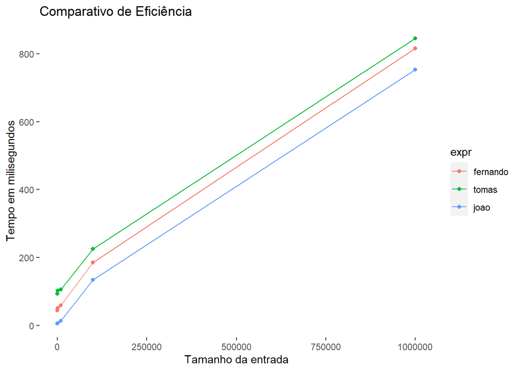

```r
library(ggplot2)

ggplot(data=total,
       aes(x=ds_size, y=median, group=expr, color=expr)) +
       geom_line() +
       geom_point() +
       labs(title = "Comparativo de Eficiência") +
       ylab("Tempo em milisegundos") +
       xlab("Tamanho da entrada") +
       theme(
             panel.background = element_blank()
             )
```

> **Observações:** Não estamos variando as possibilidades das letras, apenas as combinações de números, isso influencia diretamente no resultado. É provável que as performances mudem com maior variabilidade de combinações de letras e números bem como o armazenamento das estruturas. Deixaremos de ter um problema puramente *cpubound* para termos um problema *iobound* e *cpubound* juntos. Minha curiosidade se seguirá com o SparkR, Python e uma função em um BD relacional…